# Data Wrangling with dplyr

WCM Biostatistics Computing Club

Katherine Hoffman, MS

March 5, 2019

[figure not shown]

*Image courtesy of Allison Horst’s Twitter: @allison_horst*

# 1 Introduction

## 1.1 Why dplyr?

- Powerful but efficient
  - Consistent syntax
  - Fast
- Function chaining
  - Works well with entire tidyverse suite

```r
data("iris")
library(tidyverse)
```

## 1.2 Tibbles

- An “update” to the data.frame object class in R
- Updates relevant for using dplyr:
  - Vectors of length 1 are automatically recycled
  - Newly created vectors can be referenced in the same line of code
- Other perks: only the first 10 lines print to the screen so your console doesn’t get overloaded
- Read more about tibbles here: https://r4ds.had.co.nz/tibbles.html
- dplyr automatically converts objects to tbl_df (tibble data frame) objects

## 1.3 Piping

- `%>%` operator from `library(magitrr)`
- Use `%>%` to send an object (typically a dataframe) to the next function
- The function you pipe to will use the object in front of the `%>%` as its first argument

```r
iris %>% head() # equivalent to head(iris)
```

|  | Sepal.Length | Sepal.Width | Petal.Length | Petal.Width | Species |
| --- | --- | --- | --- | --- | --- |
| 1 | 5.1 | 3.5 | 1.4 | 0.2 | setosa |
| 2 | 4.9 | 3.0 | 1.4 | 0.2 | setosa |
| 3 | 4.7 | 3.2 | 1.3 | 0.2 | setosa |
| 4 | 4.6 | 3.1 | 1.5 | 0.2 | setosa |
| 5 | 5.0 | 3.6 | 1.4 | 0.2 | setosa |
| 6 | 5.4 | 3.9 | 1.7 | 0.4 | setosa |

```r
iris %>% head(n=3) # equivalent to head(iris, n=3)
```

|  | Sepal.Length | Sepal.Width | Petal.Length | Petal.Width | Species |
| --- | --- | --- | --- | --- | --- |
| 1 | 5.1 | 3.5 | 1.4 | 0.2 | setosa |
| 2 | 4.9 | 3.0 | 1.4 | 0.2 | setosa |
| 3 | 4.7 | 3.2 | 1.3 | 0.2 | setosa |

- If you don’t want it to be the first argument, use `.`

```r
iris %>% lm(Sepal.Width ~ Sepal.Length, data=.)
```

```
##
## Call:
## lm(formula = Sepal.Width ~ Sepal.Length, data = .)
##
## Coefficients:
##  (Intercept)  Sepal.Length
##      3.41895      -0.06188
```

- Shortcut for `%>%` is CTRL + SHIFT + M (or CMD + SHIFT + M for OSX)
- A function that takes a data frame as the first argument, eg. `head()`, is called a **verb**
- The entire tidyverse suite operates under the verb function structure, making piping especially convenient

# 2 Main verbs

## 2.1 `arrange()`

- Sort data frame by column(s), lowest to highest

```r
arrange(iris, Petal.Length)
```

| Sepal.Length | Sepal.Width | Petal.Length | Petal.Width | Species |
| --- | --- | --- | --- | --- |
| 4.6 | 3.6 | 1.0 | 0.2 | setosa |
| 4.3 | 3.0 | 1.1 | 0.1 | setosa |
| 5.8 | 4.0 | 1.2 | 0.2 | setosa |
| 5.0 | 3.2 | 1.2 | 0.2 | setosa |
| 4.7 | 3.2 | 1.3 | 0.2 | setosa |
| 5.4 | 3.9 | 1.3 | 0.4 | setosa |
| 5.5 | 3.5 | 1.3 | 0.2 | setosa |
| 4.4 | 3.0 | 1.3 | 0.2 | setosa |
| 5.0 | 3.5 | 1.3 | 0.3 | setosa |
| 4.5 | 2.3 | 1.3 | 0.3 | setosa |

[output cut: 140 more lines]

- If you specify a variable of class factor or character, you will rearrange the rows to alphabetical order
- Use `desc()` if you want the opposite order

```r
arrange(iris, desc(Species), # sort z to a since species is a factor
        Sepal.Width)
```

| Sepal.Length | Sepal.Width | Petal.Length | Petal.Width | Species |
| --- | --- | --- | --- | --- |
| 6.0 | 2.2 | 5.0 | 1.5 | virginica |
| 4.9 | 2.5 | 4.5 | 1.7 | virginica |
| 6.7 | 2.5 | 5.8 | 1.8 | virginica |
| 5.7 | 2.5 | 5.0 | 2.0 | virginica |
| 6.3 | 2.5 | 5.0 | 1.9 | virginica |
| 7.7 | 2.6 | 6.9 | 2.3 | virginica |
| 6.1 | 2.6 | 5.6 | 1.4 | virginica |
| 5.8 | 2.7 | 5.1 | 1.9 | virginica |
| 6.4 | 2.7 | 5.3 | 1.9 | virginica |
| 6.3 | 2.7 | 4.9 | 1.8 | virginica |

[output cut: 140 more lines]

## 2.2 `mutate()`

- Add a new variable (while preserving all existing variables)

```r
mutate(iris, logSepLength = log(Sepal.Length))
```

| Sepal.Length | Sepal.Width | Petal.Length | Petal.Width | Species | logSepLength |
| --- | --- | --- | --- | --- | --- |
| 5.1 | 3.5 | 1.4 | 0.2 | setosa | 1.629241 |
| 4.9 | 3.0 | 1.4 | 0.2 | setosa | 1.589235 |
| 4.7 | 3.2 | 1.3 | 0.2 | setosa | 1.547563 |
| 4.6 | 3.1 | 1.5 | 0.2 | setosa | 1.526056 |
| 5.0 | 3.6 | 1.4 | 0.2 | setosa | 1.609438 |
| 5.4 | 3.9 | 1.7 | 0.4 | setosa | 1.686399 |
| 4.6 | 3.4 | 1.4 | 0.3 | setosa | 1.526056 |
| 5.0 | 3.4 | 1.5 | 0.2 | setosa | 1.609438 |
| 4.4 | 2.9 | 1.4 | 0.2 | setosa | 1.481605 |
| 4.9 | 3.1 | 1.5 | 0.1 | setosa | 1.589235 |

[output cut: 140 more lines]

- There’s also `transmute()` which deletes the old column(s) you use to make the new column

```r
iris %>% transmute(Length_diff = Sepal.Length - Petal.Length,
                   Width_diff = Sepal.Width - Petal.Width)
```

| Length_diff | Width_diff |
| --- | --- |
| 3.7 | 3.3 |
| 3.5 | 2.8 |
| 3.4 | 3.0 |
| 3.1 | 2.9 |
| 3.6 | 3.4 |
| 3.7 | 3.5 |
| 3.2 | 3.1 |
| 3.5 | 3.2 |
| 3.0 | 2.7 |
| 3.4 | 3.0 |

[output cut: 140 more lines]

## 2.3 `filter()`

- Return rows matching specified conditions
- Use with `>`, `>=`, `<`, `<=`, `|`, `!`, `%in%`, `==`, and `!=`. Separating conditions by `,` represents the `&` argument.

```r
iris %>% filter(Sepal.Length >= 2)
```

| Sepal.Length | Sepal.Width | Petal.Length | Petal.Width | Species |
| --- | --- | --- | --- | --- |
| 5.1 | 3.5 | 1.4 | 0.2 | setosa |
| 4.9 | 3.0 | 1.4 | 0.2 | setosa |
| 4.7 | 3.2 | 1.3 | 0.2 | setosa |
| 4.6 | 3.1 | 1.5 | 0.2 | setosa |
| 5.0 | 3.6 | 1.4 | 0.2 | setosa |
| 5.4 | 3.9 | 1.7 | 0.4 | setosa |
| 4.6 | 3.4 | 1.4 | 0.3 | setosa |
| 5.0 | 3.4 | 1.5 | 0.2 | setosa |
| 4.4 | 2.9 | 1.4 | 0.2 | setosa |
| 4.9 | 3.1 | 1.5 | 0.1 | setosa |

[output cut: 140 more lines]

```r
iris %>% filter(Petal.Length >= mean(Petal.Length))
```

| Sepal.Length | Sepal.Width | Petal.Length | Petal.Width | Species |
| --- | --- | --- | --- | --- |
| 7.0 | 3.2 | 4.7 | 1.4 | versicolor |
| 6.4 | 3.2 | 4.5 | 1.5 | versicolor |
| 6.9 | 3.1 | 4.9 | 1.5 | versicolor |
| 5.5 | 2.3 | 4.0 | 1.3 | versicolor |
| 6.5 | 2.8 | 4.6 | 1.5 | versicolor |
| 5.7 | 2.8 | 4.5 | 1.3 | versicolor |
| 6.3 | 3.3 | 4.7 | 1.6 | versicolor |
| 6.6 | 2.9 | 4.6 | 1.3 | versicolor |
| 5.2 | 2.7 | 3.9 | 1.4 | versicolor |
| 5.9 | 3.0 | 4.2 | 1.5 | versicolor |

[output cut: 83 more lines]

```r
iris %>% filter(Species != "versicolor")
```

| Sepal.Length | Sepal.Width | Petal.Length | Petal.Width | Species |
| --- | --- | --- | --- | --- |
| 5.1 | 3.5 | 1.4 | 0.2 | setosa |
| 4.9 | 3.0 | 1.4 | 0.2 | setosa |
| 4.7 | 3.2 | 1.3 | 0.2 | setosa |
| 4.6 | 3.1 | 1.5 | 0.2 | setosa |
| 5.0 | 3.6 | 1.4 | 0.2 | setosa |
| 5.4 | 3.9 | 1.7 | 0.4 | setosa |
| 4.6 | 3.4 | 1.4 | 0.3 | setosa |
| 5.0 | 3.4 | 1.5 | 0.2 | setosa |
| 4.4 | 2.9 | 1.4 | 0.2 | setosa |
| 4.9 | 3.1 | 1.5 | 0.1 | setosa |

[output cut: 90 more lines]

```r
iris %>% filter(Species %in% c("versicolor", "setosa"))
```

| Sepal.Length | Sepal.Width | Petal.Length | Petal.Width | Species |
| --- | --- | --- | --- | --- |
| 5.1 | 3.5 | 1.4 | 0.2 | setosa |
| 4.9 | 3.0 | 1.4 | 0.2 | setosa |
| 4.7 | 3.2 | 1.3 | 0.2 | setosa |
| 4.6 | 3.1 | 1.5 | 0.2 | setosa |
| 5.0 | 3.6 | 1.4 | 0.2 | setosa |
| 5.4 | 3.9 | 1.7 | 0.4 | setosa |
| 4.6 | 3.4 | 1.4 | 0.3 | setosa |
| 5.0 | 3.4 | 1.5 | 0.2 | setosa |
| 4.4 | 2.9 | 1.4 | 0.2 | setosa |
| 4.9 | 3.1 | 1.5 | 0.1 | setosa |

[output cut: 90 more lines]

## 2.4 `select()`

- Keep only specified variables

```r
select(iris, Sepal.Length, Sepal.Width)
```

| Sepal.Length | Sepal.Width |
| --- | --- |
| 5.1 | 3.5 |
| 4.9 | 3.0 |
| 4.7 | 3.2 |
| 4.6 | 3.1 |
| 5.0 | 3.6 |
| 5.4 | 3.9 |
| 4.6 | 3.4 |
| 5.0 | 3.4 |
| 4.4 | 2.9 |
| 4.9 | 3.1 |

[output cut: 140 more lines]

- Specify variables to exclude with `-`

```r
select(iris, -Species)
```

| Sepal.Length | Sepal.Width | Petal.Length | Petal.Width |
| --- | --- | --- | --- |
| 5.1 | 3.5 | 1.4 | 0.2 |
| 4.9 | 3.0 | 1.4 | 0.2 |
| 4.7 | 3.2 | 1.3 | 0.2 |
| 4.6 | 3.1 | 1.5 | 0.2 |
| 5.0 | 3.6 | 1.4 | 0.2 |
| 5.4 | 3.9 | 1.7 | 0.4 |
| 4.6 | 3.4 | 1.4 | 0.3 |
| 5.0 | 3.4 | 1.5 | 0.2 |
| 4.4 | 2.9 | 1.4 | 0.2 |
| 4.9 | 3.1 | 1.5 | 0.1 |

[output cut: 140 more lines]

- Select a range of variables with `:`

```r
select(iris, Sepal.Length:Petal.Length)
```

| Sepal.Length | Sepal.Width | Petal.Length |
| --- | --- | --- |
| 5.1 | 3.5 | 1.4 |
| 4.9 | 3.0 | 1.4 |
| 4.7 | 3.2 | 1.3 |
| 4.6 | 3.1 | 1.5 |
| 5.0 | 3.6 | 1.4 |
| 5.4 | 3.9 | 1.7 |
| 4.6 | 3.4 | 1.4 |
| 5.0 | 3.4 | 1.5 |
| 4.4 | 2.9 | 1.4 |
| 4.9 | 3.1 | 1.5 |

[output cut: 140 more lines]

- If you select just one column, you will still get a dataframe. If you need a vector, use `pull()`

```r
pull(iris, Sepal.Length)
```

```
##   [1] 5.1 4.9 4.7 4.6 5.0 5.4 4.6 5.0 4.4 4.9 5.4 4.8 4.8 4.3 5.8 5.7 5.4
##  [18] 5.1 5.7 5.1 5.4 5.1 4.6 5.1 4.8 5.0 5.0 5.2 5.2 4.7 4.8 5.4 5.2 5.5
##  [35] 4.9 5.0 5.5 4.9 4.4 5.1 5.0 4.5 4.4 5.0 5.1 4.8 5.1 4.6 5.3 5.0 7.0
##  [52] 6.4 6.9 5.5 6.5 5.7 6.3 4.9 6.6 5.2 5.0 5.9 6.0 6.1 5.6 6.7 5.6 5.8
##  [69] 6.2 5.6 5.9 6.1 6.3 6.1 6.4 6.6 6.8 6.7 6.0 5.7 5.5 5.5 5.8 6.0 5.4
##  [86] 6.0 6.7 6.3 5.6 5.5 5.5 6.1 5.8 5.0 5.6 5.7 5.7 6.2 5.1 5.7 6.3 5.8
## [103] 7.1 6.3 6.5 7.6 4.9 7.3 6.7 7.2 6.5 6.4 6.8 5.7 5.8 6.4 6.5 7.7 7.7
## [120] 6.0 6.9 5.6 7.7 6.3 6.7 7.2 6.2 6.1 6.4 7.2 7.4 7.9 6.4 6.3 6.1 7.7
## [137] 6.3 6.4 6.0 6.9 6.7 6.9 5.8 6.8 6.7 6.7 6.3 6.5 6.2 5.9
```

## 2.5 `summarise()`

- Condenses data down to one value per group

```r
summarise(iris, mean(Petal.Length))
```

| mean(Petal.Length) |
| --- |
| 3.758 |

```r
summarise(iris, sd_pl = sd(Petal.Length), var_pl = sd(Petal.Length)^2)
```

| sd_pl | var_pl |
| --- | --- |
| 1.765298 | 3.116278 |

## 2.6 `group_by()`

- Invisibly groups data by specified column(s)
- Use with other verbs to get grouped information

```r
iris %>% group_by(Species)
```

| Sepal.Length | Sepal.Width | Petal.Length | Petal.Width | Species |
| --- | --- | --- | --- | --- |
| 5.1 | 3.5 | 1.4 | 0.2 | setosa |
| 4.9 | 3.0 | 1.4 | 0.2 | setosa |
| 4.7 | 3.2 | 1.3 | 0.2 | setosa |
| 4.6 | 3.1 | 1.5 | 0.2 | setosa |
| 5.0 | 3.6 | 1.4 | 0.2 | setosa |
| 5.4 | 3.9 | 1.7 | 0.4 | setosa |
| 4.6 | 3.4 | 1.4 | 0.3 | setosa |
| 5.0 | 3.4 | 1.5 | 0.2 | setosa |
| 4.4 | 2.9 | 1.4 | 0.2 | setosa |
| 4.9 | 3.1 | 1.5 | 0.1 | setosa |

[output cut: 140 more lines]

```r
iris %>%
  group_by(Species) %>%
  summarise(mean(Petal.Length), sd(Petal.Length))
```

| Species | mean(Petal.Length) | sd(Petal.Length) |
| --- | --- | --- |
| setosa | 1.462 | 0.1736640 |
| versicolor | 4.260 | 0.4699110 |
| virginica | 5.552 | 0.5518947 |

- Data will remain grouped until you use `ungroup()`

## 2.7 `rename()`

- Give your columns new names. Syntax is newColumn = oldColumn.

```r
iris %>% rename(sep_len = Sepal.Length)
```

| sep_len | Sepal.Width | Petal.Length | Petal.Width | Species |
| --- | --- | --- | --- | --- |
| 5.1 | 3.5 | 1.4 | 0.2 | setosa |
| 4.9 | 3.0 | 1.4 | 0.2 | setosa |
| 4.7 | 3.2 | 1.3 | 0.2 | setosa |
| 4.6 | 3.1 | 1.5 | 0.2 | setosa |
| 5.0 | 3.6 | 1.4 | 0.2 | setosa |
| 5.4 | 3.9 | 1.7 | 0.4 | setosa |
| 4.6 | 3.4 | 1.4 | 0.3 | setosa |
| 5.0 | 3.4 | 1.5 | 0.2 | setosa |
| 4.4 | 2.9 | 1.4 | 0.2 | setosa |
| 4.9 | 3.1 | 1.5 | 0.1 | setosa |

[output cut: 140 more lines]

# 3 Helper functions

## 3.1 `everything()`

- Move columns to the front of your data

```r
select(iris, Species, everything())
```

| Species | Sepal.Length | Sepal.Width | Petal.Length | Petal.Width |
| --- | --- | --- | --- | --- |
| setosa | 5.1 | 3.5 | 1.4 | 0.2 |
| setosa | 4.9 | 3.0 | 1.4 | 0.2 |
| setosa | 4.7 | 3.2 | 1.3 | 0.2 |
| setosa | 4.6 | 3.1 | 1.5 | 0.2 |
| setosa | 5.0 | 3.6 | 1.4 | 0.2 |
| setosa | 5.4 | 3.9 | 1.7 | 0.4 |
| setosa | 4.6 | 3.4 | 1.4 | 0.3 |
| setosa | 5.0 | 3.4 | 1.5 | 0.2 |
| setosa | 4.4 | 2.9 | 1.4 | 0.2 |
| setosa | 4.9 | 3.1 | 1.5 | 0.1 |

[output cut: 140 more lines]

## 3.2 `starts_with()`

```r
select(iris, starts_with("Petal"))
```

| Petal.Length | Petal.Width |
| --- | --- |
| 1.4 | 0.2 |
| 1.4 | 0.2 |
| 1.3 | 0.2 |
| 1.5 | 0.2 |
| 1.4 | 0.2 |
| 1.7 | 0.4 |
| 1.4 | 0.3 |
| 1.5 | 0.2 |
| 1.4 | 0.2 |
| 1.5 | 0.1 |

[output cut: 140 more lines]

## 3.3 `ends_with()`

```r
select(iris, ends_with("Length"))
```

| Sepal.Length | Petal.Length |
| --- | --- |
| 5.1 | 1.4 |
| 4.9 | 1.4 |
| 4.7 | 1.3 |
| 4.6 | 1.5 |
| 5.0 | 1.4 |
| 5.4 | 1.7 |
| 4.6 | 1.4 |
| 5.0 | 1.5 |
| 4.4 | 1.4 |
| 4.9 | 1.5 |

[output cut: 140 more lines]

## 3.4 `contains()`

- Searches column names for a specified string

```r
select(iris, contains("Wid"))
```

| Sepal.Width | Petal.Width |
| --- | --- |
| 3.5 | 0.2 |
| 3.0 | 0.2 |
| 3.2 | 0.2 |
| 3.1 | 0.2 |
| 3.6 | 0.2 |
| 3.9 | 0.4 |
| 3.4 | 0.3 |
| 3.4 | 0.2 |
| 2.9 | 0.2 |
| 3.1 | 0.1 |

[output cut: 140 more lines]

## 3.5 `matches()`

- Searches column names for a specified regular expression

```r
select(iris, matches("wid|spec"))
```

| Sepal.Width | Petal.Width | Species |
| --- | --- | --- |
| 3.5 | 0.2 | setosa |
| 3.0 | 0.2 | setosa |
| 3.2 | 0.2 | setosa |
| 3.1 | 0.2 | setosa |
| 3.6 | 0.2 | setosa |
| 3.9 | 0.4 | setosa |
| 3.4 | 0.3 | setosa |
| 3.4 | 0.2 | setosa |
| 2.9 | 0.2 | setosa |
| 3.1 | 0.1 | setosa |

[output cut: 140 more lines]

For more info on regex see [here](https://medium.com/factory-mind/regex-tutorial-a-simple-cheatsheet-by-examples-649dc1c3f285)

## 3.6 `row_number()`

- Specify which row number you want for your verb

```r
iris %>%
  group_by(Species) %>%
  filter(row_number() == 1)
```

| Sepal.Length | Sepal.Width | Petal.Length | Petal.Width | Species |
| --- | --- | --- | --- | --- |
| 5.1 | 3.5 | 1.4 | 0.2 | setosa |
| 7.0 | 3.2 | 4.7 | 1.4 | versicolor |
| 6.3 | 3.3 | 6.0 | 2.5 | virginica |

## 3.7 `n()`

- References the number of rows in your data frame (or for each group in a `'grouped_df'`)

```r
iris %>%
  group_by(Species) %>%
  filter(row_number() == n())
```

| Sepal.Length | Sepal.Width | Petal.Length | Petal.Width | Species |
| --- | --- | --- | --- | --- |
| 5.0 | 3.3 | 1.4 | 0.2 | setosa |
| 5.7 | 2.8 | 4.1 | 1.3 | versicolor |
| 5.9 | 3.0 | 5.1 | 1.8 | virginica |

# 4 Fancy verbs

- Scoped verbs take the additional arguments **.predicate**, **.funs**, and **.vars**
- They end in `_at()`, `_if()` and `_all()`
- Signify what function (**.funs**) should be applied too `all` variables, only `at` certain variables (**.vars**), or only `if` variables meet a certain condition (**.predicate**)
- ie. `mutate_at()`, `mutate_if()`, `mutate_all()`, `summarise_if()`, `summarise_at()`, `summarise_all()`, `select_if()`, `select_at()`, `rename_if()`, `filter_all()`, `arrange_all()`, `group_by_at()` …the list goes on!
- A few examples (we will see more later)

```r
iris %>% select_if(.predicate = is.numeric)
```

| Sepal.Length | Sepal.Width | Petal.Length | Petal.Width |
| --- | --- | --- | --- |
| 5.1 | 3.5 | 1.4 | 0.2 |
| 4.9 | 3.0 | 1.4 | 0.2 |
| 4.7 | 3.2 | 1.3 | 0.2 |
| 4.6 | 3.1 | 1.5 | 0.2 |
| 5.0 | 3.6 | 1.4 | 0.2 |
| 5.4 | 3.9 | 1.7 | 0.4 |
| 4.6 | 3.4 | 1.4 | 0.3 |
| 5.0 | 3.4 | 1.5 | 0.2 |
| 4.4 | 2.9 | 1.4 | 0.2 |
| 4.9 | 3.1 | 1.5 | 0.1 |

[output cut: 140 more lines]

```r
iris %>% select_if(.predicate = is.numeric, .funs=funs(paste0("num_",.))) # can also be used to rename
```

| num_Sepal.Length | num_Sepal.Width | num_Petal.Length | num_Petal.Width |
| --- | --- | --- | --- |
| 5.1 | 3.5 | 1.4 | 0.2 |
| 4.9 | 3.0 | 1.4 | 0.2 |
| 4.7 | 3.2 | 1.3 | 0.2 |
| 4.6 | 3.1 | 1.5 | 0.2 |
| 5.0 | 3.6 | 1.4 | 0.2 |
| 5.4 | 3.9 | 1.7 | 0.4 |
| 4.6 | 3.4 | 1.4 | 0.3 |
| 5.0 | 3.4 | 1.5 | 0.2 |
| 4.4 | 2.9 | 1.4 | 0.2 |
| 4.9 | 3.1 | 1.5 | 0.1 |

[output cut: 140 more lines]

```r
iris %>% summarise_if(.predicate = is.numeric, .funs = funs(mean(., na.rm=T)))
```

| Sepal.Length | Sepal.Width | Petal.Length | Petal.Width |
| --- | --- | --- | --- |
| 5.843333 | 3.057333 | 3.758 | 1.199333 |

```r
iris %>% mutate_at(.vars = vars(c("Sepal.Length","Petal.Length")),
                                         .funs = funs(scale))
```

| Sepal.Length | Sepal.Width | Petal.Length | Petal.Width | Species |
| --- | --- | --- | --- | --- |
| -0.89767388 | 3.5 | -1.33575163 | 0.2 | setosa |
| -1.13920048 | 3.0 | -1.33575163 | 0.2 | setosa |
| -1.38072709 | 3.2 | -1.39239929 | 0.2 | setosa |
| -1.50149039 | 3.1 | -1.27910398 | 0.2 | setosa |
| -1.01843718 | 3.6 | -1.33575163 | 0.2 | setosa |
| -0.53538397 | 3.9 | -1.16580868 | 0.4 | setosa |
| -1.50149039 | 3.4 | -1.33575163 | 0.3 | setosa |
| -1.01843718 | 3.4 | -1.27910398 | 0.2 | setosa |
| -1.74301699 | 2.9 | -1.33575163 | 0.2 | setosa |
| -1.13920048 | 3.1 | -1.27910398 | 0.1 | setosa |

[output cut: 140 more lines]

```r
# z scores by Species for all numeric variables
iris %>% group_by(Species) %>%
  mutate_if(.predicate = is.numeric, .funs = funs(scale))
```

| Sepal.Length | Sepal.Width | Petal.Length | Petal.Width | Species |
| --- | --- | --- | --- | --- |
| 0.26667447 | 0.18994136 | -0.35701125 | -0.43649232 | setosa |
| -0.30071802 | -1.12909583 | -0.35701125 | -0.43649232 | setosa |
| -0.86811050 | -0.60148096 | -0.93283584 | -0.43649232 | setosa |
| -1.15180675 | -0.86528840 | 0.21881335 | -0.43649232 | setosa |
| -0.01702177 | 0.45374879 | -0.35701125 | -0.43649232 | setosa |
| 1.11776320 | 1.24517111 | 1.37046253 | 1.46130036 | setosa |
| -1.15180675 | -0.07386608 | -0.35701125 | 0.51240402 | setosa |
| -0.01702177 | -0.07386608 | 0.21881335 | -0.43649232 | setosa |
| -1.71919923 | -1.39290327 | -0.35701125 | -0.43649232 | setosa |
| -0.30071802 | -0.86528840 | 0.21881335 | -1.38538866 | setosa |

[output cut: 140 more lines]

- I have never used any of the `group_by_*()` but I imagine they’re useful when you have a large selection of identifiers/grouping variables that you can call easily with a predicate (for example, `is.factor`). They can also be used with a **.funs** argument as a shortcut to `group_by() %>% mutate()`.

# 5 Miscellaneous verbs

## 5.1 `lag()`

- Makes a new column with the value of one row previously

## 5.2 `lead()`

- Makes a new column with the value of one row ahead

```r
x <- runif(5)
cbind(ahead = lead(x), x, behind = lag(x))
```

```
##           ahead          x     behind
## [1,] 0.01750923 0.69201174         NA
## [2,] 0.26307797 0.01750923 0.69201174
## [3,] 0.04004479 0.26307797 0.01750923
## [4,] 0.41882181 0.04004479 0.26307797
## [5,]         NA 0.41882181 0.04004479
```

- Can choose a time column to order your new values by with the argument `'order_by'`
- Lag and lead are very useful for longitudinal models

## 5.3 `complete()`

```r
incomplete_df <- data.frame(day = c(1,3,7,9), dose = c(0, 25, 40, 30))
incomplete_df
```

| day | dose |
| --- | --- |
| 1 | 0 |
| 3 | 25 |
| 7 | 40 |
| 9 | 30 |

```r
complete(incomplete_df, day = full_seq(1:max(day), 1))
```

| day | dose |
| --- | --- |
| 1 | 0 |
| 2 | NA |
| 3 | 25 |
| 4 | NA |
| 5 | NA |
| 6 | NA |
| 7 | 40 |
| 8 | NA |
| 9 | 30 |

## 5.4 `fill()`

- Fill in missing values with values before or after

```r
incomplete_df %>%
  complete(day = full_seq(1:max(day), 1)) %>%
  fill(dose, .direction = "down")
```

| day | dose |
| --- | --- |
| 1 | 0 |
| 2 | 0 |
| 3 | 25 |
| 4 | 25 |
| 5 | 25 |
| 6 | 25 |
| 7 | 40 |
| 8 | 40 |
| 9 | 30 |

## 5.5 `drop_na()`

```r
incomplete_df %>%
  complete(day = full_seq(1:max(day), 1)) %>%
  drop_na() # when you have more variables, specify which columns you care about dropping NAs from
```

| day | dose |
| --- | --- |
| 1 | 0 |
| 3 | 25 |
| 7 | 40 |
| 9 | 30 |

## 5.6 `sample_frac()`

- Randomly sample a specified fraction of rows of a data frame

```r
mydat <- data.frame(id = sample(1:100, 20), meas = rnorm(20))
mydat
```

| id | meas |
| --- | --- |
| 5 | 0.03229888 |
| 8 | 1.16334971 |
| 21 | -0.93476042 |
| 45 | 0.10942060 |
| 7 | -0.80676176 |
| 35 | -0.90772332 |
| 20 | 0.74038257 |
| 31 | 1.05454910 |
| 26 | 0.96409765 |
| 93 | -0.81664696 |

[output cut: 10 more lines]

```r
mydat %>% sample_frac(size = .5)
```

|  | id | meas |
| --- | --- | --- |
| 18 | 44 | -1.85468034 |
| 1 | 5 | 0.03229888 |
| 9 | 26 | 0.96409765 |
| 6 | 35 | -0.90772332 |
| 20 | 63 | -0.54983104 |
| 8 | 31 | 1.05454910 |
| 4 | 45 | 0.10942060 |
| 12 | 91 | 0.41841307 |
| 2 | 8 | 1.16334971 |
| 16 | 95 | -1.74625211 |

```r
mydat %>% sample_frac(size= .5, replace = T) # you can also add sampling weights
```

|  | id | meas |
| --- | --- | --- |
| 14 | 38 | 2.10027082 |
| 8 | 31 | 1.05454910 |
| 3 | 21 | -0.93476042 |
| 11 | 29 | 0.66686535 |
| 19 | 34 | -0.07381232 |
| 7 | 20 | 0.74038257 |
| 4 | 45 | 0.10942060 |
| 12 | 91 | 0.41841307 |
| 4.1 | 45 | 0.10942060 |
| 12.1 | 91 | 0.41841307 |

## 5.7 `sample_n()`

- Randomly sample a specified number of rows of a data frame

```r
mydat %>% sample_n(3)
```

|  | id | meas |
| --- | --- | --- |
| 9 | 26 | 0.9640976 |
| 12 | 91 | 0.4184131 |
| 8 | 31 | 1.0545491 |

# 6 Joining functions

```r
x <- data.frame(id = c("A","B","C"), val = 1:3)
y <- data.frame(id = c("A","B","D"), val = c("T","F","T"))
x
```

```
##   id val
## 1  A   1
## 2  B   2
## 3  C   3
```

```r
y
```

```
##   id val
## 1  A   T
## 2  B   F
## 3  D   T
```

- “Mutating” joins combine variables from the left and right hand sides ie. `full_join()`, `inner_join()`, `right_join()`, and `left_join()`

## 6.1 `full_join()`

- Return all rows and columns

```r
full_join(x, y, by = "id")
```

```
##   id val.x val.y
## 1  A     1     T
## 2  B     2     F
## 3  C     3  <NA>
## 4  D    NA     T
```

## 6.2 `inner_join()`

- Return all rows from `x` that have a match in `y`, and all columns from `x` and `y`

```r
inner_join(x, y, by = "id")
```

```
##   id val.x val.y
## 1  A     1     T
## 2  B     2     F
```

## 6.3 `left_join()`

- Return all rows from `x` and all columns from `x` and `y`

```r
left_join(x, y, by = "id")
```

```
##   id val.x val.y
## 1  A     1     T
## 2  B     2     F
## 3  C     3  <NA>
```

## 6.4 `right_join()`

```r
right_join(x, y, by = "id")
```

```
##   id val.x val.y
## 1  A     1     T
## 2  B     2     F
## 3  D    NA     T
```

- “Filtering” joins keep cases from the left hand side, ie. `semi_join()` and `anti_join()`

## 6.5 `semi_join()`

```r
semi_join(x, y, by = "id")
```

```
##   id val
## 1  A   1
## 2  B   2
```

## 6.6 `anti_join()`

- Return all rows from `x` where there are not matching values in `y`, keeping just the columns from `x`

```r
anti_join(x, y, by = "id")
```

```
##   id val
## 1  C   3
```

# 7 Incorporating dplyr into your workflow

## 7.1 Frequency Tables

```r
library(kableExtra)
mtcars %>%
  group_by(vs, am) %>%
  summarise(n=n(), freq=n()/nrow(.)) %>%
  kable(caption="Frequency Table of vs and am", format="html") %>%
  kable_styling(c("condensed","responsive","striped","hover"), full_width = F)
```

Frequency Table of vs and am

| vs | am | n | freq |
| --- | --- | --- | --- |
| 0 | 0 | 12 | 0.37500 |
| 0 | 1 | 6 | 0.18750 |
| 1 | 0 | 7 | 0.21875 |
| 1 | 1 | 7 | 0.21875 |

## 7.2 compareGroups

```r
library(compareGroups)
iris %>%
  mutate(Sepal.Length.Sq = Sepal.Length^2) %>%
  compareGroups(Species ~ ., data = .) %>%
  createTable() %>%
  export2md() %>%
  kable_styling(c("condensed","responsive","striped","hover"))
```

Summary descriptives table by groups of `Species’

|  | setosa | versicolor | virginica | p.overall |
| --- | --- | --- | --- | --- |
|  | N=50 | N=50 | N=50 |  |
| Sepal.Length | 5.01 (0.35) | 5.94 (0.52) | 6.59 (0.64) | <0.001 |
| Sepal.Width | 3.43 (0.38) | 2.77 (0.31) | 2.97 (0.32) | <0.001 |
| Petal.Length | 1.46 (0.17) | 4.26 (0.47) | 5.55 (0.55) | <0.001 |
| Petal.Width | 0.25 (0.11) | 1.33 (0.20) | 2.03 (0.27) | <0.001 |
| Sepal.Length.Sq | 25.2 (3.55) | 35.5 (6.16) | 43.8 (8.44) | <0.001 |

## 7.3 ggplotting

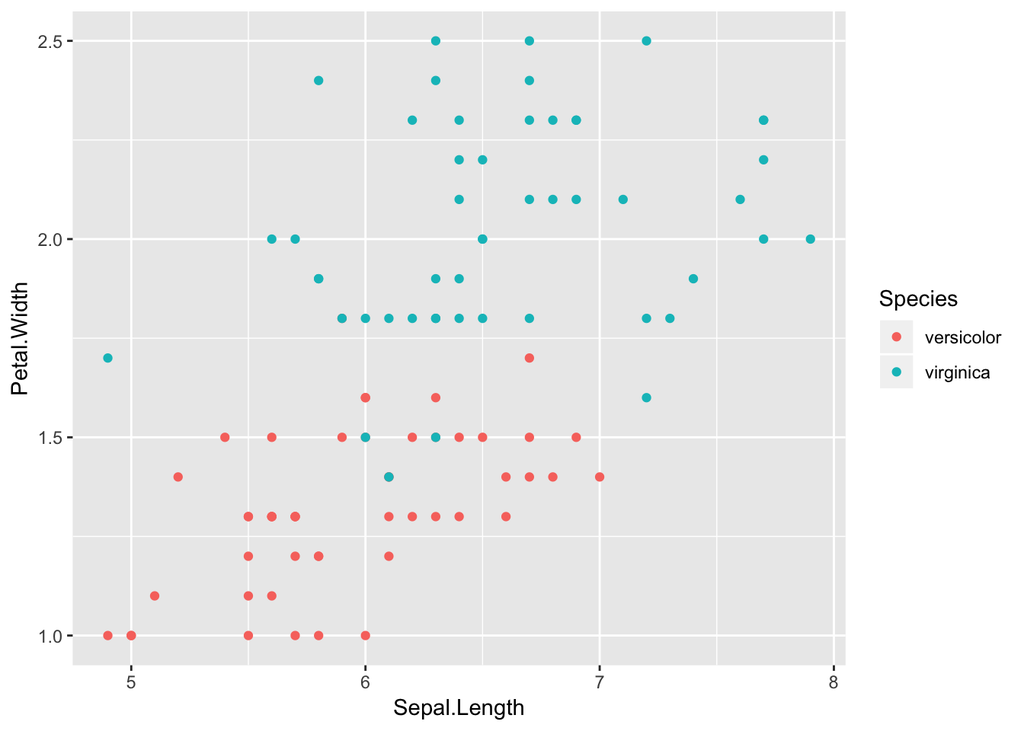

```r
iris %>%
  filter(Species != "setosa") %>%
  ggplot(aes(Sepal.Length, Petal.Width, col=Species)) +
  geom_point()
```

## 7.4 Finding columns of interest

- When you have too many column names to look through manually, search for a string or pattern of strings

```r
load("dplyr_dat.Rdata")
length(names(brain))
```

```
## [1] 1000
```

```r
select(brain, matches("pib.*parietal.*")) %>% names() # regex is not case sensitive
```

```
## [1] "PIB.PET_AAL__Parietal_Inf_L"
## [2] "PIB.PET_AAL__Parietal_Inf_R"
## [3] "PIB.PET_AAL__Parietal_Sup_L"
## [4] "PIB.PET_AAL__Parietal_Sup_R"
## [5] "PIB.PET_FS__ctx.lh.inferiorparietal"
## [6] "PIB.PET_FS__ctx.lh.superiorparietal"
## [7] "PIB.PET_FS__ctx.rh.inferiorparietal"
## [8] "PIB.PET_FS__ctx.rh.superiorparietal"
```

## 7.5 Missing data wrangling

- Add a column flagging a value as missing and then replace the missing values with the mean of the other values

```r
misdat <- data.frame(x1 = sample(c(1:3, NA), 13, replace=T),
                     x2 = sample(c(-5:-2,NA), 13, replace=T))
misdat
```

| x1 | x2 |
| --- | --- |
| 2 | -4 |
| 1 | -5 |
| 3 | NA |
| NA | -4 |
| 3 | -3 |
| NA | NA |
| 3 | -5 |
| NA | -5 |
| 1 | -5 |
| 2 | -2 |

[output cut: 3 more lines]

```r
misdat %>%
  mutate_all(.funs = funs(miss = ifelse(is.na(.), 1, 0))) %>%
  mutate_all(.funs = funs(replace_na(., mean(., na.rm=T))))
```

| x1 | x2 | x1_miss | x2_miss |
| --- | --- | --- | --- |
| 2.0 | -4.000000 | 0 | 0 |
| 1.0 | -5.000000 | 0 | 0 |
| 3.0 | -3.636364 | 0 | 1 |
| 2.2 | -4.000000 | 1 | 0 |
| 3.0 | -3.000000 | 0 | 0 |
| 2.2 | -3.636364 | 1 | 1 |
| 3.0 | -5.000000 | 0 | 0 |
| 2.2 | -5.000000 | 1 | 0 |
| 1.0 | -5.000000 | 0 | 0 |
| 2.0 | -2.000000 | 0 | 0 |

[output cut: 3 more lines]

## 7.6 Longitudinal data wrangling A

- Calculate the time since a patient was first admitted to the hospital

```r
id <- c(1,1,1,2,2,2,2,3)
admit <- as.Date(c("2017-06-22", "2017-07-13", "2017-08-29",
                   "2017-04-01", "2017-05-02", "2017-11-14", "2018-01-14",
                   "2019-01-01"))
discharge <- as.Date(c("2017-06-25", "2017-07-31", "2017-10-13",
                   "2017-04-02", "2017-05-10", "2017-11-18", "2018-02-12",
                   "2019-01-05"))
hosp_dat <- data.frame(id, admit, discharge)
hosp_dat
```

| id | admit | discharge |
| --- | --- | --- |
| 1 | 2017-06-22 | 2017-06-25 |
| 1 | 2017-07-13 | 2017-07-31 |
| 1 | 2017-08-29 | 2017-10-13 |
| 2 | 2017-04-01 | 2017-04-02 |
| 2 | 2017-05-02 | 2017-05-10 |
| 2 | 2017-11-14 | 2017-11-18 |
| 2 | 2018-01-14 | 2018-02-12 |
| 3 | 2019-01-01 | 2019-01-05 |

```r
hosp_dat %>%
  group_by(id) %>%
  mutate(days_since_init_admit = discharge - admit[1])
```

| id | admit | discharge | days_since_init_admit |
| --- | --- | --- | --- |
| 1 | 2017-06-22 | 2017-06-25 | 3 days |
| 1 | 2017-07-13 | 2017-07-31 | 39 days |
| 1 | 2017-08-29 | 2017-10-13 | 113 days |
| 2 | 2017-04-01 | 2017-04-02 | 1 days |
| 2 | 2017-05-02 | 2017-05-10 | 39 days |
| 2 | 2017-11-14 | 2017-11-18 | 231 days |
| 2 | 2018-01-14 | 2018-02-12 | 317 days |
| 3 | 2019-01-01 | 2019-01-05 | 4 days |

## 7.7 Longitudinal data wrangling B

- Make a row for every patient for every month from the start of follow up to the end of follow up (get equally spaced time intervals)
- Make another column containing the drugs the patient was on previously (for prediction or longitudinal models)

```r
load("meds.Rdata")
```

```r
meds
```

|  | PatientID | Months_ImplantToVisit | BB_yn | ACE_yn | ARB_yn |
| --- | --- | --- | --- | --- | --- |
| 1 | 1 | 1 | 0 | 0 | 0 |
| 2 | 1 | 2 | 0 | 0 | 0 |
| 3 | 2 | 2 | 0 | 1 | 0 |
| 4 | 2 | 3 | 0 | 1 | 0 |
| 5 | 2 | 4 | 0 | 1 | 0 |
| 6 | 2 | 5 | 0 | 1 | 0 |
| 7 | 2 | 6 | 1 | 1 | 0 |
| 8 | 2 | 8 | 1 | 1 | 0 |
| 9 | 2 | 10 | 1 | 1 | 0 |
| 10 | 2 | 12 | 1 | 1 | 0 |

[output cut: 2522 more lines]

```r
meds %>%
    group_by(PatientID) %>%
    complete(Months_ImplantToVisit = full_seq(1:max(Months_ImplantToVisit), 1)) %>%
    fill(ends_with("_yn")) %>%
    fill(ends_with("_yn"), .direction="up") -> meds1
meds1
```

| PatientID | Months_ImplantToVisit | BB_yn | ACE_yn | ARB_yn |
| --- | --- | --- | --- | --- |
| 1 | 1 | 0 | 0 | 0 |
| 1 | 2 | 0 | 0 | 0 |
| 2 | 1 | 0 | 1 | 0 |
| 2 | 2 | 0 | 1 | 0 |
| 2 | 3 | 0 | 1 | 0 |
| 2 | 4 | 0 | 1 | 0 |
| 2 | 5 | 0 | 1 | 0 |
| 2 | 6 | 1 | 1 | 0 |
| 2 | 7 | 1 | 1 | 0 |
| 2 | 8 | 1 | 1 | 0 |

[output cut: 6476 more lines]

```r
meds1 %>%
  mutate_at(.vars = vars(ends_with("_yn")),
              .funs = funs(prev = lag(., order_by = Months_ImplantToVisit))) %>%
    fill(ends_with("_prev"), .direction="up")
```

| PatientID | Months_ImplantToVisit | BB_yn | ACE_yn | ARB_yn | BB_yn_prev | ACE_yn_prev | ARB_yn_prev |
| --- | --- | --- | --- | --- | --- | --- | --- |
| 1 | 1 | 0 | 0 | 0 | 0 | 0 | 0 |
| 1 | 2 | 0 | 0 | 0 | 0 | 0 | 0 |
| 2 | 1 | 0 | 1 | 0 | 0 | 1 | 0 |
| 2 | 2 | 0 | 1 | 0 | 0 | 1 | 0 |
| 2 | 3 | 0 | 1 | 0 | 0 | 1 | 0 |
| 2 | 4 | 0 | 1 | 0 | 0 | 1 | 0 |
| 2 | 5 | 0 | 1 | 0 | 0 | 1 | 0 |
| 2 | 6 | 1 | 1 | 0 | 0 | 1 | 0 |
| 2 | 7 | 1 | 1 | 0 | 1 | 1 | 0 |
| 2 | 8 | 1 | 1 | 0 | 1 | 1 | 0 |

[output cut: 6476 more lines]

## 7.8 Survival data wrangling

- Map four columns “days to…outcome” to a composite endpoint for a survival model
- Record *when* the event occurred as Days.to.first.event and *which* event it was in FE.status

```r
dems %>%
  select(Days.to.lastFU, Days.to.death, Days.to.stroke, Days.to.GIB, Days.to.PT) %>%
  # which.min cannot handle NA, so we'll make NA's infinity for now
  replace(is.na(.), Inf) %>%
  # to allow which.min to search along rows (dplyr naturally looks down columns)
  rowwise() %>%
  mutate(
    FUorFEtime = pmin(Days.to.lastFU, Days.to.death, Days.to.stroke,
                      Days.to.GIB, Days.to.PT,
                      na.rm = T),
    # numbers correspond to order of the Days* columns
    FUorFEstatus = which.min(c(Days.to.lastFU, Days.to.death, Days.to.stroke,
                                    Days.to.GIB, Days.to.PT)),
    # condensed variable for survival model, 1 if any event
  Event_yn = ifelse(FUorFEstatus == 1, 0, 1)) -> dems_int

dems_int # look at the intermediate output
```

| Days.to.lastFU | Days.to.death | Days.to.stroke | Days.to.GIB | Days.to.PT | FUorFEtime | FUorFEstatus | Event_yn |
| --- | --- | --- | --- | --- | --- | --- | --- |
| 98 | 98 | 94 | Inf | Inf | 94 | 3 | 1 |
| 163 | Inf | Inf | Inf | 141 | 141 | 5 | 1 |
| 185 | Inf | Inf | Inf | Inf | 185 | 1 | 0 |
| 139 | Inf | Inf | Inf | Inf | 139 | 1 | 0 |
| 196 | Inf | Inf | 78 | Inf | 78 | 4 | 1 |
| 161 | Inf | Inf | Inf | Inf | 161 | 1 | 0 |
| 210 | Inf | 185 | Inf | Inf | 185 | 3 | 1 |
| 233 | Inf | Inf | Inf | Inf | 233 | 1 | 0 |
| 239 | Inf | Inf | Inf | Inf | 239 | 1 | 0 |
| 243 | Inf | Inf | Inf | Inf | 243 | 1 | 0 |

[output cut: 255 more lines]

```r
dems_int %>%
  # column names correspond to the order of the columns, rename
  mutate(FUorFEstatus = case_when(FUorFEstatus == 1 ~ "censored",
                                  FUorFEstatus == 2 ~ "death",
                                  FUorFEstatus == 3 ~ "stroke",
                                  FUorFEstatus == 4 ~ "gib",
                                  FUorFEstatus == 5 ~ "pt",
                                  TRUE ~ "error")) %>%
  # not case sensitive
  select(contains("fe"), Event_yn) %>%
  # allow for joining with no duplicate cols
  rownames_to_column() %>%
  full_join(dems %>% rownames_to_column()) %>%
  select(-rowname) -> dems_clean

# check to make sure everything worked
dems_clean %>% filter(FUorFEstatus == "error")
```

| FUorFEtime | FUorFEstatus | Event_yn | PatientID | Year.of.Implant | Outcome | Days.to.lastFU | Stroke | Days.to.stroke | TypeStroke | Stroke_IA | Days.to.IA.stroke | TypeStroke_IA | PT | Days.to.PT | GIB | Days.to.GIB | GIB_IA | Days.to.GIB_IA | Age.at.implant | Sex | Race | Caucasian | AfibFlut | Smoking_Hx | DM | Ischemic | HTN_Hx | Stroke_Hx | Pulmonary_Hx | … |
| --- | --- | --- | --- | --- | --- | --- | --- | --- | --- | --- | --- | --- | --- | --- | --- | --- | --- | --- | --- | --- | --- | --- | --- | --- | --- | --- | --- | --- | --- | --- |

```r
dems_clean
```

| FUorFEtime | FUorFEstatus | Event_yn | PatientID | Year.of.Implant | Outcome | Days.to.lastFU | Stroke | Days.to.stroke | TypeStroke | Stroke_IA | Days.to.IA.stroke | TypeStroke_IA | PT | Days.to.PT | GIB | Days.to.GIB | GIB_IA | Days.to.GIB_IA | Age.at.implant | Sex | Race | Caucasian | AfibFlut | Smoking_Hx | DM | Ischemic | HTN_Hx | Stroke_Hx | Pulmonary_Hx | … |
| --- | --- | --- | --- | --- | --- | --- | --- | --- | --- | --- | --- | --- | --- | --- | --- | --- | --- | --- | --- | --- | --- | --- | --- | --- | --- | --- | --- | --- | --- | --- |
| 94 | stroke | 1 | 1 | 2016 | 2 | 98 | 1 | 94 | 2 | 0 | NA | NA | 0 | NA | 0 | NA | 0 | NA | 55 | Male | 5 | 1 | Yes | Yes | No | 1 | No | No | No | … |
| 141 | pt | 1 | 2 | 2016 | 7 | 163 | 0 | NA | NA | 0 | NA | NA | 1 | 141 | 0 | NA | 0 | NA | 73 | Female | 2 | 0 | Yes | No | No | 1 | No | No | No | … |
| 185 | censored | 0 | 3 | 2016 | 7 | 185 | 0 | NA | NA | 0 | NA | NA | 0 | NA | 0 | NA | 1 | 15 | 70 | Female | 3 | 0 | No | No | No | 0 | Yes | Yes | Yes | … |
| 139 | censored | 0 | 4 | 2016 | 6 | 139 | 0 | NA | NA | 0 | NA | NA | 0 | NA | 0 | NA | 0 | NA | 71 | Male | 5 | 1 | No | Yes | Yes | 1 | No | Yes | Yes | … |
| 78 | gib | 1 | 5 | 2016 | 7 | 196 | 0 | NA | NA | 0 | NA | NA | 0 | NA | 1 | 78 | 0 | NA | 77 | Female | 3 | 0 | No | Yes | Yes | 1 | Yes | No | Yes | … |
| 161 | censored | 0 | 6 | 2016 | 1 | 161 | 0 | NA | NA | 0 | NA | NA | 0 | NA | 0 | NA | 0 | NA | 24 | Female | 5 | 1 | No | No | No | 0 | No | No | No | … |
| 185 | stroke | 1 | 7 | 2016 | 7 | 210 | 1 | 185 | 1 | 0 | NA | NA | 0 | NA | 0 | NA | 0 | NA | 32 | Male | 5 | 1 | No | Yes | No | 0 | Yes | Yes | No | … |
| 233 | censored | 0 | 8 | 2016 | 7 | 233 | 0 | NA | NA | 0 | NA | NA | 0 | NA | 0 | NA | 0 | NA | 45 | Male | 5 | 1 | No | No | No | 0 | No | No | Yes | … |
| 239 | censored | 0 | 9 | 2016 | 7 | 239 | 0 | NA | NA | 0 | NA | NA | 0 | NA | 0 | NA | 1 | 8 | 62 | Male | 5 | 1 | No | Yes | No | 1 | Yes | No | Yes | … |
| 243 | censored | 0 | 10 | 2016 | 7 | 243 | 0 | NA | NA | 0 | NA | NA | 0 | NA | 0 | NA | 0 | NA | 62 | Female | 3 | 0 | No | Yes | No | 0 | No | No | No | … |

[output cut: 255 more lines]

## 7.9 Making functions

- Problem: dplyr doesn’t know what to do with quotes around the variable name, but you can’t put the column name into a function without quotes because R will try to find it as an object in your environment…
- Solution: relying on the rlang package (sym, !!, !!!, etc)
- A good tutorial: http://jonthegeek.com/2018/06/04/writing-custom-tidyverse-functions/

```r
irisSummary <- function(group){
    iris %>%
      group_by(!!sym(group)) %>%
      summarise(mean(Sepal.Length), sd(Sepal.Length))
}

irisSummary(group = "Species")
```

| Species | mean(Sepal.Length) | sd(Sepal.Length) |
| --- | --- | --- |
| setosa | 5.006 | 0.3524897 |
| versicolor | 5.936 | 0.5161711 |
| virginica | 6.588 | 0.6358796 |

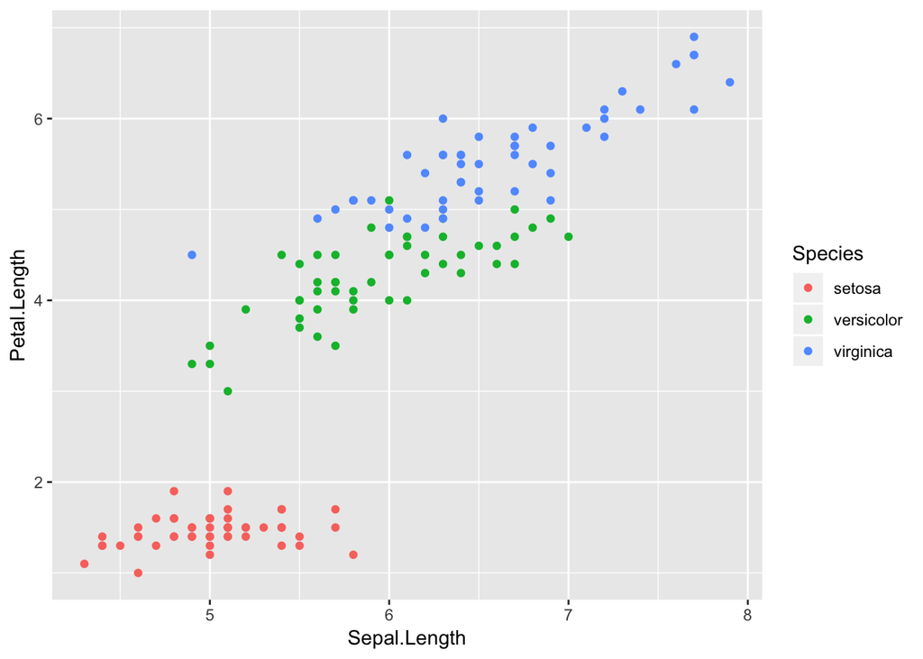

```r
irisScatPlot <- function(x, y){
    iris %>%
    ggplot(aes_string(x, y, col="Species")) +
    geom_point() -> p
  return(p)
}

irisScatPlot(x="Sepal.Length",y="Petal.Length")
```